# Multiple Disease Prediction Based On Blood Sample

### Prasanna Prakash

#### Dataset Link

https://www.kaggle.com/datasets/ehababoelnaga/multiple-disease-prediction?select=Blood_samples_dataset_balanced_2%28f%29.csv

```python
import pandas as pd
import numpy as np
```

# 1. EDA

```python
df1 = pd.read_csv('/Users/prasanna/Downloads/archive (19)/Blood_samples_dataset_balanced_2(f).csv')
df2= pd.read_csv('/Users/prasanna/Documents/UOP SEM 3/healthcare/blood_samples_dataset_test.csv')
df = pd.concat([df1, df2], axis=0, ignore_index=True)
df.shape
```

```
(2837, 25)
```

```python
df.info(verbose=True)
```

```
<class 'pandas.core.frame.DataFrame'>
RangeIndex: 2837 entries, 0 to 2836
Data columns (total 25 columns):
 #   Column                                     Non-Null Count  Dtype
---  ------                                     --------------  -----
 0   Glucose                                    2837 non-null   float64
 1   Cholesterol                                2837 non-null   float64
 2   Hemoglobin                                 2837 non-null   float64
 3   Platelets                                  2837 non-null   float64
 4   White Blood Cells                          2837 non-null   float64
 5   Red Blood Cells                            2837 non-null   float64
 6   Hematocrit                                 2837 non-null   float64
 7   Mean Corpuscular Volume                    2837 non-null   float64
 8   Mean Corpuscular Hemoglobin                2837 non-null   float64
 9   Mean Corpuscular Hemoglobin Concentration  2837 non-null   float64
```

[output cut: 17 more lines]

Except the 'Disease' column, all other columns have datatype as float.

```python
df.columns
```

```
Index(['Glucose', 'Cholesterol', 'Hemoglobin', 'Platelets',
       'White Blood Cells', 'Red Blood Cells', 'Hematocrit',
       'Mean Corpuscular Volume', 'Mean Corpuscular Hemoglobin',
       'Mean Corpuscular Hemoglobin Concentration', 'Insulin', 'BMI',
       'Systolic Blood Pressure', 'Diastolic Blood Pressure', 'Triglycerides',
       'HbA1c', 'LDL Cholesterol', 'HDL Cholesterol', 'ALT', 'AST',
       'Heart Rate', 'Creatinine', 'Troponin', 'C-reactive Protein',
       'Disease'],
      dtype='object')
```

## 1.2 Brief information about Column Names / Features

Glucose (Blood Glucose) – The primary sugar in the blood that provides energy to cells.

Cholesterol (Total Cholesterol) – A type of fat in the blood, essential for building cells but harmful in excess.

Hemoglobin (Hb) – A protein in red blood cells that carries oxygen throughout the body.

Platelets (Thrombocytes) – Small blood components that help with clotting and stop bleeding.

White Blood Cells (WBCs or Leukocytes) – Cells that fight infections and play a role in immunity.

Red Blood Cells (RBCs or Erythrocytes) – Cells that carry oxygen from the lungs to the rest of the body.

Hematocrit (Hct) – The proportion of red blood cells in the blood, indicating oxygen-carrying capacity.

Mean Corpuscular Volume (MCV) – A measure of the average size of red blood cells, used in diagnosing anemia types.

Mean Corpuscular Hemoglobin (MCH) – The average amount of hemoglobin per red blood cell, used to assess anemia.

Mean Corpuscular Hemoglobin Concentration (MCHC) – The average concentration of hemoglobin in red blood cells.

Insulin – A hormone produced by the pancreas that regulates blood glucose levels.

BMI (Body Mass Index) – A measurement of body fat based on height and weight.

Systolic Blood Pressure (SBP) – The pressure in blood vessels when the heart beats (top number in BP readings).

Diastolic Blood Pressure (DBP) – The pressure in blood vessels between heartbeats (bottom number in BP readings).

Triglycerides – A type of fat in the blood that, in excess, increases the risk of heart disease.

HbA1c (Hemoglobin A1c) – A measure of average blood glucose levels over the past 2-3 months, used in diabetes management.

LDL Cholesterol (Low-Density Lipoprotein Cholesterol) – Often referred to as "bad cholesterol," high levels increase the risk of heart disease.

HDL Cholesterol (High-Density Lipoprotein Cholesterol) – Known as "good cholesterol," it helps remove excess cholesterol from the bloodstream.

ALT (Alanine Aminotransferase) – An enzyme found in the liver, elevated levels indicate liver damage.

AST (Aspartate Aminotransferase) – An enzyme found in the liver and heart, used to diagnose liver or heart damage.

Heart Rate (HR) – The number of times the heart beats per minute.

Creatinine – A waste product from muscle metabolism, used to assess kidney function.

Troponin – A protein released into the blood after a heart attack, indicating heart muscle damage.

C-reactive Protein (CRP) – A protein that increases in the blood during inflammation or infection.

Disease – A condition that impairs normal functioning and usually has recognizable symptoms and signs.

```python
df.describe()
```

|  | Glucose | Cholesterol | Hemoglobin | Platelets | White Blood Cells | Red Blood Cells | Hematocrit | Mean Corpuscular Volume | Mean Corpuscular Hemoglobin | Mean Corpuscular Hemoglobin Concentration | ... | Triglycerides | HbA1c | LDL Cholesterol | HDL Cholesterol | ALT | AST | Heart Rate | Creatinine | Troponin | C-reactive Protein |
| --- | --- | --- | --- | --- | --- | --- | --- | --- | --- | --- | --- | --- | --- | --- | --- | --- | --- | --- | --- | --- | --- |
| count | 2837.000000 | 2837.000000 | 2837.000000 | 2837.000000 | 2837.000000 | 2837.000000 | 2837.000000 | 2837.000000 | 2837.000000 | 2837.000000 | ... | 2837.000000 | 2837.000000 | 2837.000000 | 2837.000000 | 2837.000000 | 2837.000000 | 2837.000000 | 2837.000000 | 2837.000000 | 2837.000000 |
| mean | 0.384621 | 0.413031 | 0.568941 | 0.508157 | 0.510863 | 0.506205 | 0.506106 | 0.496309 | 0.488859 | 0.551795 | ... | 0.395643 | 0.447721 | 0.435470 | 0.536118 | 0.446217 | 0.460282 | 0.567101 | 0.440572 | 0.464101 | 0.445221 |
| std | 0.262080 | 0.251023 | 0.278908 | 0.301621 | 0.279597 | 0.273070 | 0.287049 | 0.276560 | 0.310724 | 0.277234 | ... | 0.266795 | 0.269223 | 0.260077 | 0.274450 | 0.271631 | 0.253810 | 0.260580 | 0.242565 | 0.259814 | 0.254098 |
| min | 0.001827 | 0.003088 | 0.000719 | 0.000006 | -0.000206 | 0.000552 | 0.004556 | 0.000309 | -0.000614 | 0.000719 | ... | 0.001885 | -0.000991 | 0.001036 | -0.000546 | -0.000312 | 0.002047 | 0.002145 | 0.008831 | 0.005714 | -0.000991 |
| 25% | 0.141529 | 0.223545 | 0.325035 | 0.202496 | 0.259467 | 0.258357 | 0.288132 | 0.287532 | 0.217207 | 0.319725 | ... | 0.189918 | 0.188792 | 0.231304 | 0.296264 | 0.214581 | 0.239659 | 0.335346 | 0.214560 | 0.288961 | 0.199513 |
| 50% | 0.357817 | 0.397638 | 0.597916 | 0.533962 | 0.527381 | 0.467431 | 0.493428 | 0.461418 | 0.448926 | 0.583470 | ... | 0.335778 | 0.466375 | 0.424560 | 0.512941 | 0.389440 | 0.486317 | 0.599542 | 0.428713 | 0.465957 | 0.489070 |
| 75% | 0.596150 | 0.603341 | 0.791215 | 0.771727 | 0.744950 | 0.743670 | 0.753657 | 0.722293 | 0.778160 | 0.741381 | ... | 0.597671 | 0.670665 | 0.619900 | 0.779378 | 0.715823 | 0.620868 | 0.800666 | 0.645247 | 0.684140 | 0.633088 |
| max | 0.991742 | 0.999606 | 0.997876 | 0.999507 | 0.999646 | 1.000000 | 1.000857 | 0.996362 | 0.999234 | 0.999666 | ... | 0.999826 | 0.999265 | 0.999567 | 1.000744 | 1.000326 | 1.000402 | 0.999857 | 0.999348 | 1.000125 | 0.999488 |

8 rows × 24 columns

The range of values of all columns make it clear that the data is already scaled (0-1).

## 1.3 Check Missing Values

```python
missing_values =df.isnull().sum()
missing_values
```

```
Glucose                                      0
Cholesterol                                  0
Hemoglobin                                   0
Platelets                                    0
White Blood Cells                            0
Red Blood Cells                              0
Hematocrit                                   0
Mean Corpuscular Volume                      0
Mean Corpuscular Hemoglobin                  0
Mean Corpuscular Hemoglobin Concentration    0
Insulin                                      0
BMI                                          0
Systolic Blood Pressure                      0
Diastolic Blood Pressure                     0
Triglycerides                                0
HbA1c                                        0
LDL Cholesterol                              0
HDL Cholesterol                              0
ALT                                          0
AST                                          0
Heart Rate                                   0
Creatinine                                   0
Troponin                                     0
C-reactive Protein                           0
Disease                                      0
dtype: int64
```

Data does not have any missing values

## 1.4 Analyze Distributions and Outliers

It seems that data is scaled which will make it difficult to know the outliers visually. We will therefore calculate z scores to look for outliers.

Instead of plotting each feature one by one, you can use automated statistical methods to identify potential outliers for all features at once. This will help you quickly spot which features require more in-depth investigation.

**Z-Score Calculation for All Continuous Features**

We will calculate the z-scores for all continuous features at once and flag rows where any feature has an unusually high z-score (|z| > 3).

## 1.4.1. Z-Score Calculation for All Continuous Features

```python
# Identify continuous columns (i.e., numerical features)
continuous_columns = df.select_dtypes(include=['float64', 'int64']).columns
print(f"Continuous columns: {continuous_columns}")
```

```
Continuous columns: Index(['Glucose', 'Cholesterol', 'Hemoglobin', 'Platelets',
       'White Blood Cells', 'Red Blood Cells', 'Hematocrit',
       'Mean Corpuscular Volume', 'Mean Corpuscular Hemoglobin',
       'Mean Corpuscular Hemoglobin Concentration', 'Insulin', 'BMI',
       'Systolic Blood Pressure', 'Diastolic Blood Pressure', 'Triglycerides',
       'HbA1c', 'LDL Cholesterol', 'HDL Cholesterol', 'ALT', 'AST',
       'Heart Rate', 'Creatinine', 'Troponin', 'C-reactive Protein'],
      dtype='object')
```

```python
from scipy.stats import zscore

# Select only the continuous columns (exclude categorical columns if any)
continuous_columns = ['Glucose', 'Cholesterol', 'Hemoglobin', 'Platelets', 'White Blood Cells',
                      'Red Blood Cells', 'Hematocrit', 'Mean Corpuscular Volume',
                      'Mean Corpuscular Hemoglobin', 'Mean Corpuscular Hemoglobin Concentration',
                      'Insulin', 'BMI', 'Systolic Blood Pressure', 'Diastolic Blood Pressure',
                      'Triglycerides', 'HbA1c', 'LDL Cholesterol', 'HDL Cholesterol', 'ALT',
                      'AST', 'Heart Rate', 'Creatinine', 'Troponin', 'C-reactive Protein']

# Calculate the z-scores for all continuous features
z_scores = df[continuous_columns].apply(zscore)

# Flag rows where any feature has a z-score > 3
outliers = (z_scores.abs() > 3).any(axis=1)

# Check how many rows have outliers
print(f"Number of rows with potential outliers: {outliers.sum()}")
```

```
Number of rows with potential outliers: 0
```

## 1.4.2. Understand Data Distribution through Histograms

We will plot histograms of all numeric features. This will help us to :

**Understand Data Distribution:** Histograms show whether features follow a normal, skewed, or uniform distribution, crucial for selecting appropriate statistical tests and models.

**Identify Outliers:** Visualize outliers as distant bars, which could distort your analysis or machine learning models.

**Feature Transformation:** Guide whether features need transformations (e.g., log, scaling) based on skewness or kurtosis for better model performance.

**Detect Class Imbalance:** If applicable, observe any imbalance in numerical target variables.

**Model Assumptions:** Ensure data fits the assumptions required by certain models (e.g., normality for linear models).

**Bin Frequency:** Analyze the frequency of data points in specific intervals to understand the data spread.

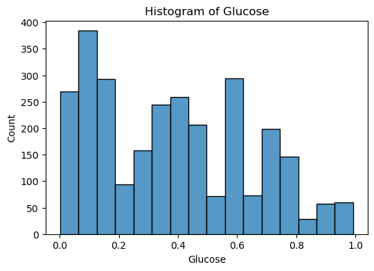

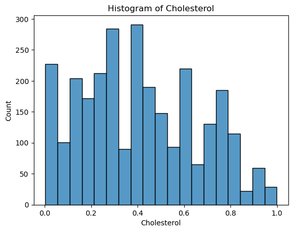

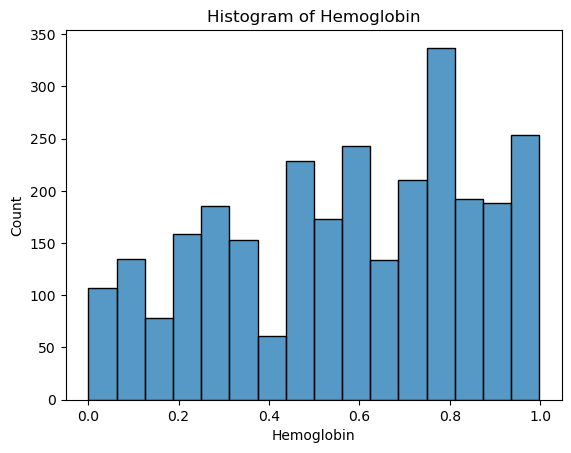

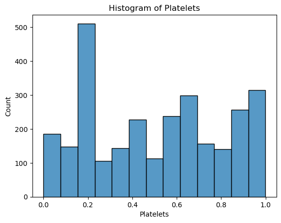

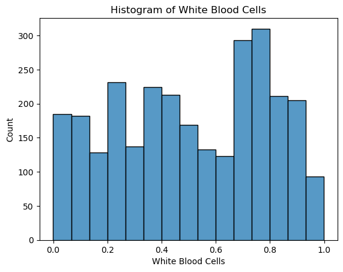

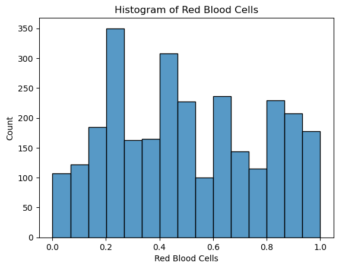

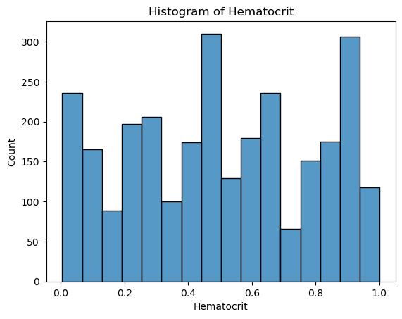

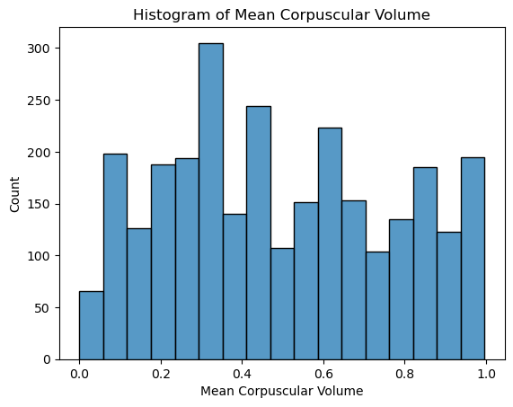

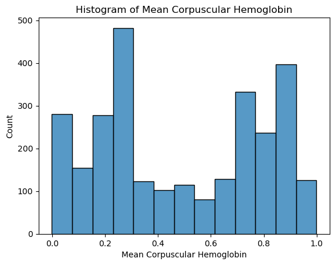

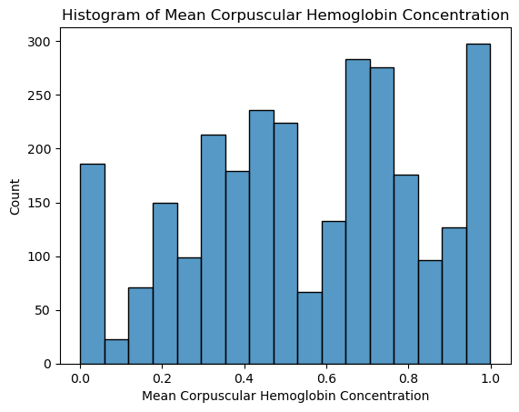

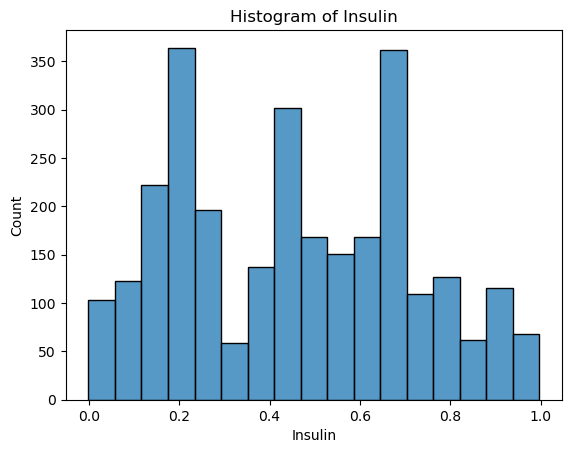

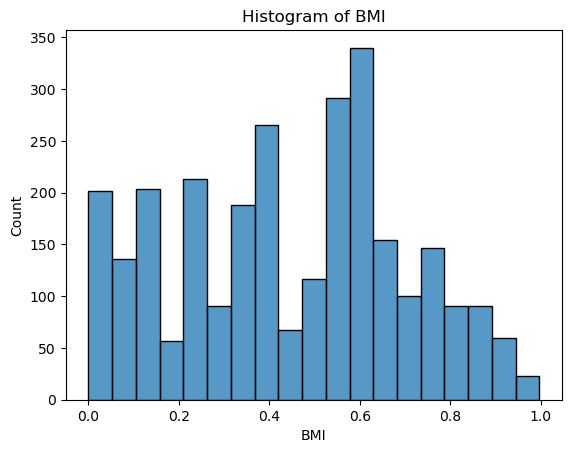

[12 more figures not shown]

```python
import seaborn as sns
import matplotlib.pyplot as plt

# creating new df of only numeric columns
numeric_df = df.drop('Disease', axis=1)


# plot histogram of all numeric columns
plt.figure(figsize=(6,4))
for col in numeric_df.columns:
    sns.histplot(numeric_df[col])
    plt.title(f'Histogram of {col}')
    plt.tight_layout
    plt.show()
```

Clustering is present in some features (e.g., HDL Cholesterol) with two distinct peaks, while gaps exist in certain features like Systolic Blood Pressure.

# 2. Feature Selection

## 2.1 Correlation Matrix

We will not plot correlation matrix which will help us to :

**dentify Relationships:** Detect linear relationships between numerical features. High positive (near +1) or negative (near -1) correlations suggest a strong linear relationship.

**Feature Selection:** Identify redundant features (e.g., highly correlated features) that could cause multicollinearity in models, helping decide which to drop or combine.

**Data Insights:** Understand feature interactions that could be crucial for model interpretation or feature engineering.

**Multicollinearity Detection:** High correlations between independent variables can affect model stability, leading to inaccurate coefficient estimates in linear models.

**Guide Model Selection:** Features with weak or no correlation may require non-linear models, while strongly correlated features suit linear models.

**Improves Interpretability:** Visually highlights relationships that might be difficult to spot from raw data, enhancing data understanding.

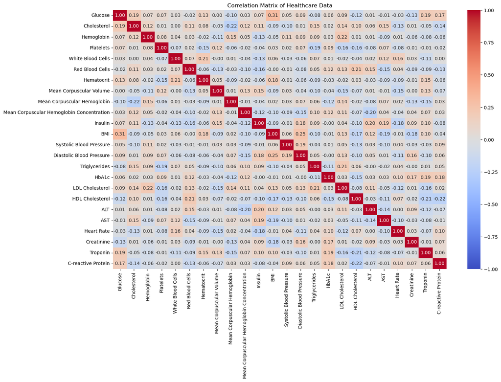

```python
import pandas as pd
import matplotlib.pyplot as plt
import seaborn as sns

# Calculate the correlation matrix
corr_matrix = df.corr()

# Plot the heatmap for visualization
plt.figure(figsize=(16, 10))
sns.heatmap(corr_matrix, annot=True, cmap='coolwarm', fmt='.2f', vmin=-1, vmax=1)
plt.title("Correlation Matrix of Healthcare Data")
plt.show()
```

**Weak Correlations:**

Many pairs (e.g., Glucose & Platelets) show weak or no correlation.

## 2.2 Check Normality

## 2.2.1 QQ Plots

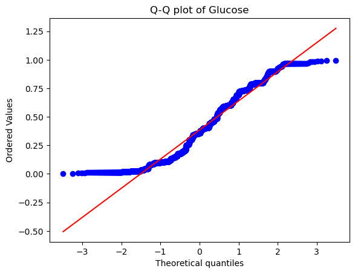

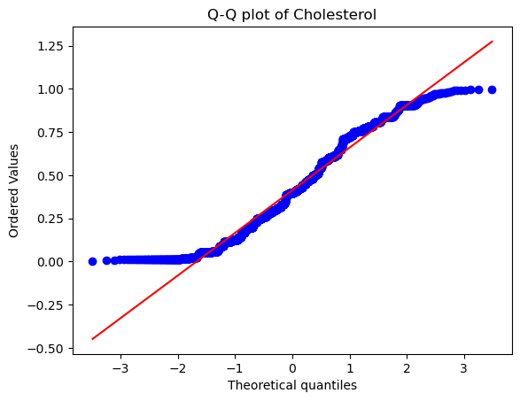

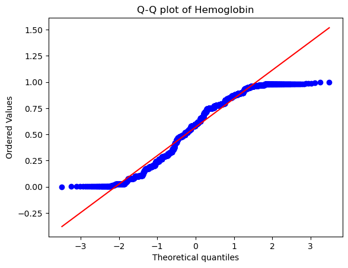

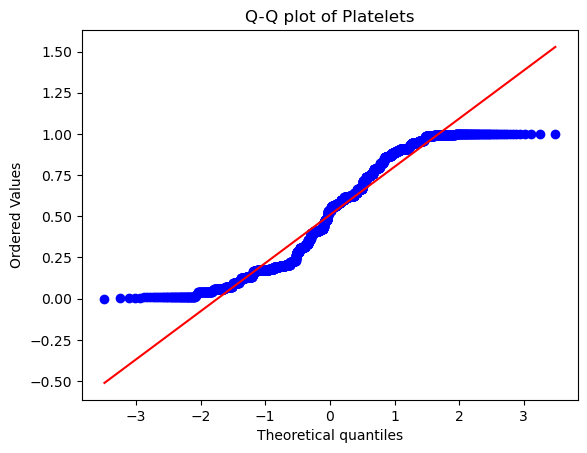

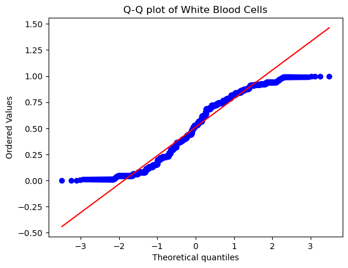

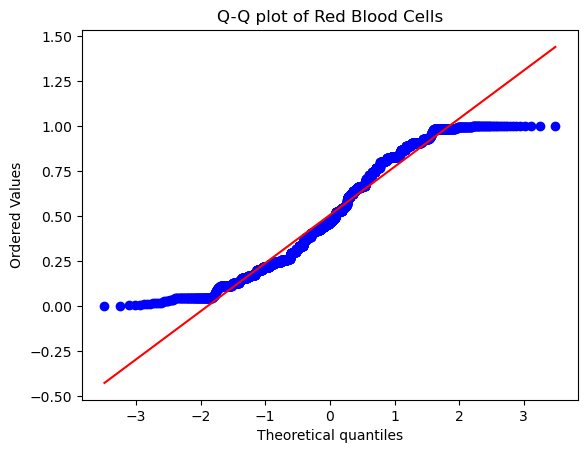

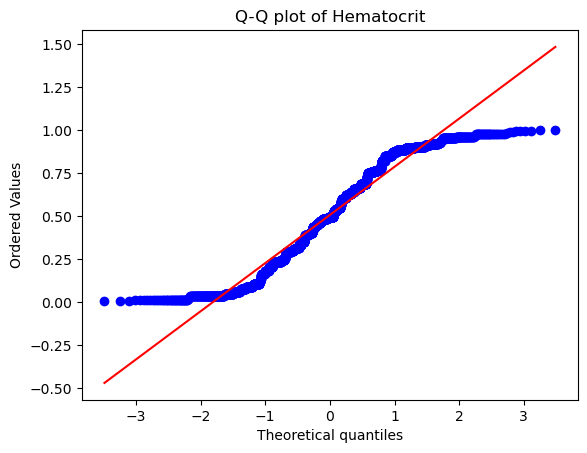

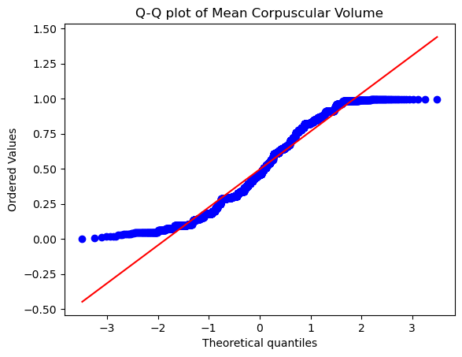

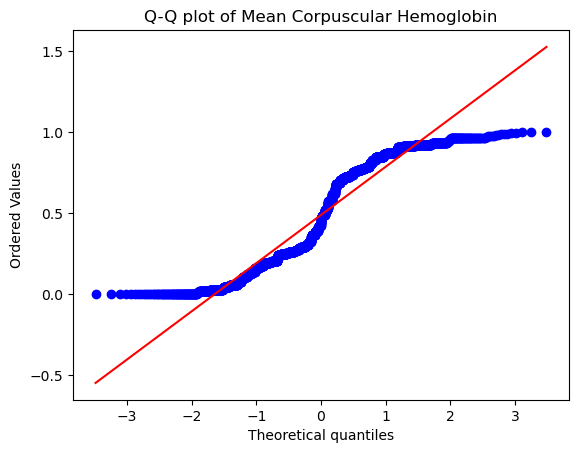

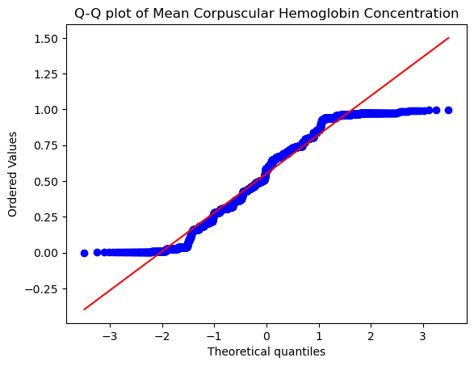

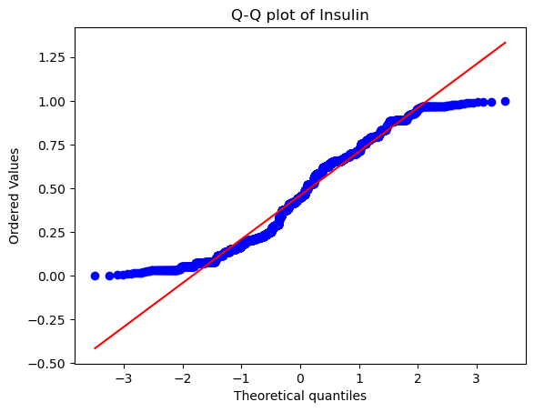

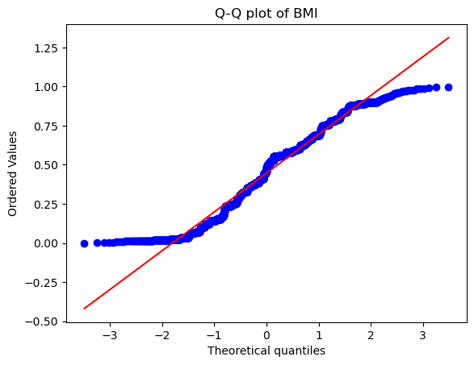

[12 more figures not shown]

```python
import scipy.stats as stats
import matplotlib.pyplot as plt

# Loop through all features and generate Q-Q plots
for column in numeric_df.columns:
    stats.probplot(numeric_df[column], dist="norm", plot=plt)
    plt.title(f"Q-Q plot of {column}")
    plt.show()
```

Small deviations from the red line are more common when working with scaled data, particularly at the left and right tails.

In scaled data, the center will give you the most meaningful information about normality.

We expect more deviation at the tails: The tails will typically show more variance from the red line due to the compressed range of scaled data.

## 2.2.2 Shapiro-Wilk Test ( for checking Normality)

This statistical test used to determine whether a sample comes from a normally distributed population.

it is Best for smaller datasets (typically <5000 rows).

**Null Hypothesis (H0):** Data is normally distributed.

**Alternative Hypothesis (H1):** Data is not normally distributed.

Ideal For: Checking normality of individual features one by one

```python
from scipy.stats import shapiro

# Check normality for each numeric column and display the result
for column in numeric_df.columns:
    stat, p_value = shapiro(numeric_df[column])
    normality = "Normal" if p_value > 0.05 else "Not Normal"
    print(f"{column}: p-value = {p_value}, {normality}")
```

```
Glucose: p-value = 7.71432226639562e-31, Not Normal
Cholesterol: p-value = 1.8801995544520574e-25, Not Normal
Hemoglobin: p-value = 3.4197218343387404e-30, Not Normal
Platelets: p-value = 5.563379663571722e-33, Not Normal
White Blood Cells: p-value = 2.6066758381461705e-30, Not Normal
Red Blood Cells: p-value = 7.2352132444524435e-28, Not Normal
Hematocrit: p-value = 3.899296822242583e-30, Not Normal
Mean Corpuscular Volume: p-value = 1.3925077758439767e-28, Not Normal
Mean Corpuscular Hemoglobin: p-value = 4.6860241807921977e-38, Not Normal
Mean Corpuscular Hemoglobin Concentration: p-value = 1.0059418100131274e-27, Not Normal
Insulin: p-value = 5.636780175981474e-27, Not Normal
BMI: p-value = 8.799793687623095e-25, Not Normal
Systolic Blood Pressure: p-value = 3.2288882370895253e-28, Not Normal
Diastolic Blood Pressure: p-value = 1.255013346310781e-30, Not Normal
Triglycerides: p-value = 1.3951911416858869e-30, Not Normal
HbA1c: p-value = 3.507743453181421e-29, Not Normal
LDL Cholesterol: p-value = 3.4968552250927147e-25, Not Normal
HDL Cholesterol: p-value = 1.4897543019553002e-30, Not Normal
ALT: p-value = 2.8992600216902216e-33, Not Normal
AST: p-value = 4.559975121661505e-23, Not Normal
Heart Rate: p-value = 2.2483637430727026e-27, Not Normal
Creatinine: p-value = 1.5484699852598134e-25, Not Normal
Troponin: p-value = 5.59868783931646e-23, Not Normal
C-reactive Protein: p-value = 8.086370460210537e-30, Not Normal
```

**Observations:**

p-values for all features are significantly less than 0.05, which means we reject the null hypothesis for all features.

None of the features follow a normal distribution.

## 2.3 Check Equality of Variances (Levene’s Test )

parametric tests, like ANOVA, assume homoscedasticity (equal variance) across groups. Violating this assumption can distort test results, leading to inflated Type I error rates (false positives) and misleading conclusions about group differences.

Levene’s Test is used to assess whether variances across groups (disease classes) are statistically equal:

If p-value > 0.05: Variances are equal, and tests assuming homoscedasticity (e.g., ANOVA) are appropriate.

If p-value < 0.05: Variances are unequal (heteroscedasticity).

In case of heteroscedasticity, we will use Kruskal-Wallis (for non-normal data), a non-parametric alternative. We will not use Welch’s ANOVA because it is for normal data.

**Importance:**

Ignoring variance inequality can lead to incorrect conclusions, overstating the significance of group differences. Levene’s Test ensures that subsequent statistical tests are chosen based on the true variance structure, improving the accuracy of the analysis.

```python
import scipy.stats as stats

# Running Levene's Test for each feature and printing both results
for feature in continuous_columns:
    groups = [df[df['Disease'] == category][feature] for category in df['Disease'].unique()]
    _, p_value = stats.levene(*groups)

    if p_value < 0.05:
        print(f"{feature} has unequal variance (p-value: {p_value})")
    else:
        print(f"{feature} has equal variance (p-value: {p_value})")
```

```
Glucose has unequal variance (p-value: 5.875205367727902e-40)
Cholesterol has unequal variance (p-value: 1.372240310078675e-81)
Hemoglobin has unequal variance (p-value: 7.203396636465451e-65)
Platelets has unequal variance (p-value: 7.61979494363857e-70)
White Blood Cells has unequal variance (p-value: 1.0447498836926315e-12)
Red Blood Cells has unequal variance (p-value: 5.96704021312875e-12)
Hematocrit has unequal variance (p-value: 3.0528554109434124e-27)
Mean Corpuscular Volume has unequal variance (p-value: 1.2220013789172267e-83)
Mean Corpuscular Hemoglobin has unequal variance (p-value: 1.5401361196283143e-05)
Mean Corpuscular Hemoglobin Concentration has unequal variance (p-value: 8.1822830584853e-67)
Insulin has unequal variance (p-value: 1.6211149323994042e-16)
BMI has unequal variance (p-value: 4.7168795068226726e-64)
Systolic Blood Pressure has unequal variance (p-value: 1.3284333906075206e-13)
Diastolic Blood Pressure has unequal variance (p-value: 1.4519340099898879e-22)
Triglycerides has unequal variance (p-value: 2.1475431753310987e-67)
HbA1c has unequal variance (p-value: 1.322827013789807e-41)
LDL Cholesterol has unequal variance (p-value: 9.947468785041969e-43)
HDL Cholesterol has unequal variance (p-value: 2.413699433200813e-42)
ALT has unequal variance (p-value: 2.6935455399777663e-18)
AST has unequal variance (p-value: 4.77522010430717e-67)
Heart Rate has unequal variance (p-value: 8.716263699122473e-26)
Creatinine has unequal variance (p-value: 3.053082866469253e-64)
Troponin has unequal variance (p-value: 6.659229051524292e-39)
C-reactive Protein has unequal variance (p-value: 3.872065295577428e-52)
```

The results from Levene's test indicate that the variances for all of your features are significantly different across the different disease categories (p-value < 0.05). This suggests heteroscedasticity, meaning the assumption of equal variances (homoscedasticity) is violated.

ANOVA Assumption Violation: ANOVA assumes homogeneity of variances. Since the Levene test shows unequal variances across the categories, we cannot directly rely on standard ANOVA results.

Alternatives to Handle Unequal Variances:

**1. Welch’s ANOVA:** This is a variation of ANOVA that does not assume equal variances. It's a more appropriate test when the assumption of homoscedasticity is violated. (but since our data is not normal this is not useful for us)

**2. Kruskal-Wallis Test:** This is a non-parametric alternative to ANOVA that does not assume equal variances or normality. It’s useful when both ANOVA assumptions (normality and equal variance) are violated. Hence we will go ahead with this test

## 2.4 Kruskal-Wallis test

```python
from scipy.stats import kruskal

# Apply Kruskal-Wallis test to all continuous columns
kruskal_results = {}
for feature in continuous_columns:
    groups = [df[df['Disease'] == category][feature] for category in df['Disease'].unique()]
    _, p_value = kruskal(*groups)
    kruskal_results[feature] = p_value

# Print the results and check significance
for feature, p_value in kruskal_results.items():
    if p_value < 0.05:
        print(f"The feature '{feature}' is statistically significant with p-value: {p_value:.5f}")
    else:
        print(f"The feature '{feature}' is NOT statistically significant (p-value: {p_value:.5f})")
```

```
The feature 'Glucose' is statistically significant with p-value: 0.00000
The feature 'Cholesterol' is statistically significant with p-value: 0.00000
The feature 'Hemoglobin' is statistically significant with p-value: 0.00000
The feature 'Platelets' is statistically significant with p-value: 0.00000
The feature 'White Blood Cells' is statistically significant with p-value: 0.00000
The feature 'Red Blood Cells' is statistically significant with p-value: 0.00000
The feature 'Hematocrit' is statistically significant with p-value: 0.00000
The feature 'Mean Corpuscular Volume' is statistically significant with p-value: 0.00000
The feature 'Mean Corpuscular Hemoglobin' is statistically significant with p-value: 0.00000
The feature 'Mean Corpuscular Hemoglobin Concentration' is statistically significant with p-value: 0.00000
The feature 'Insulin' is statistically significant with p-value: 0.00000
The feature 'BMI' is statistically significant with p-value: 0.00000
The feature 'Systolic Blood Pressure' is statistically significant with p-value: 0.00000
The feature 'Diastolic Blood Pressure' is statistically significant with p-value: 0.00000
The feature 'Triglycerides' is statistically significant with p-value: 0.00000
The feature 'HbA1c' is statistically significant with p-value: 0.00000
The feature 'LDL Cholesterol' is statistically significant with p-value: 0.00000
The feature 'HDL Cholesterol' is statistically significant with p-value: 0.00000
The feature 'ALT' is statistically significant with p-value: 0.00000
The feature 'AST' is statistically significant with p-value: 0.00007
The feature 'Heart Rate' is statistically significant with p-value: 0.00000
The feature 'Creatinine' is statistically significant with p-value: 0.00000
The feature 'Troponin' is statistically significant with p-value: 0.00000
The feature 'C-reactive Protein' is statistically significant with p-value: 0.00000
```

The results from the Kruskal-Wallis test show that **all features in our dataset are statistically significant, with p-values well below the threshold of 0.05.** This indicates that the distribution of values for each feature is significantly different across the various disease categories.

**Significance of Features:** Each feature tested plays a statistically significant role in differentiating the disease categories in the dataset.

**No Feature Exclusion:** Since all features have p-values less than 0.05, we should't exclude any based on the Kruskal-Wallis test.

## 2.5 Multicollinearity Check (VIF):

Purpose: To check if any of the significant features identified by the Kruskal-Wallis test are highly correlated, which can affect the model's performance. Let's calculate the Variance Inflation Factor (VIF) to identify multicollinear features.

```python
from statsmodels.stats.outliers_influence import variance_inflation_factor
import pandas as pd

# Create a DataFrame with only significant features based on the previous Kruskal-Wallis results
signi_df = df[list(kruskal_results.keys())]

# Calculate VIF for each feature
vif_data = pd.DataFrame()
vif_data['Feature'] = signi_df.columns
vif_data['VIF'] = [variance_inflation_factor(signi_df.values, i) for i in range(signi_df.shape[1])]

# Display the VIF results
print(vif_data)
```

```
                                      Feature       VIF
0                                     Glucose  4.284181
1                                 Cholesterol  4.978098
2                                  Hemoglobin  6.094083
3                                   Platelets  4.263480
4                           White Blood Cells  5.223667
5                             Red Blood Cells  5.366392
6                                  Hematocrit  4.864520
7                     Mean Corpuscular Volume  4.812029
8                 Mean Corpuscular Hemoglobin  4.042948
9   Mean Corpuscular Hemoglobin Concentration  5.702510
10                                    Insulin  5.626919
11                                        BMI  5.939229
12                    Systolic Blood Pressure  3.908998
13                   Diastolic Blood Pressure  5.288513
14                              Triglycerides  3.936209
15                                      HbA1c  4.704871
16                            LDL Cholesterol  5.089171
17                            HDL Cholesterol  5.151713
18                                        ALT  4.478783
19                                        AST  4.957486
20                                 Heart Rate  6.168550
21                                 Creatinine  5.037780
22                                   Troponin  5.211838
23                         C-reactive Protein  4.658156
```

**VIF > 5, the feature is highly correlated and may need to be removed or handled using techniques like PCA.**

Clinical Significance: Many features in healthcare data, like Glucose, Cholesterol, or Hemoglobin, are clinically significant on their own, regardless of multicollinearity. **Removing such features based solely on VIF might lead to losing valuable insights.**

Modeling Choice: Some machine learning models, like tree-based models (e.g., Random Forest, Gradient Boosting), are less sensitive to multicollinearity. In these cases, we don’t need to worry much about VIF.

Interpretability: To use linear models (e.g., Logistic Regression) or other interpretable models, high multicollinearity could make it harder to interpret the coefficients, but not necessarily impact predictive performance significantly.

# 3. Class Distribution

```python
from scipy import stats

# Check the distribution of the target variable 'Disease'
disease_distribution = df['Disease'].value_counts()
disease_distribution
```

```
Diabetes    834
Anemia      707
Healthy     561
Thalasse    557
Thromboc    139
Heart Di     39
Name: Disease, dtype: int64
```

**Implications of Class Imbalance:**

**Misleading Accuracy:** The model might show high overall accuracy due to correct predictions for the majority classes, but this could mask poor performance on minority classes. Accuracy is not a reliable metric in imbalanced datasets.

**False Negatives in Critical Cases:** For important but rare diseases like Thrombocytopenia, high false negative rates can have serious consequences. The model may miss these cases entirely due to the class imbalance, which could be problematic in healthcare scenarios.

**Solutions to Address Class Imbalance:**

**1. Resampling:**

**Oversampling:** Increase the representation of minority classes (e.g., Thrombocytopenia) by duplicating or synthetically generating samples (e.g., with SMOTE).

**2. Use Class Weights:**

Many machine learning algorithms, such as decision trees, logistic regression, and neural networks, allow to assign class weights, which give more importance to the minority class during training.

**3. Synthetic Data Generation:**

SMOTE (Synthetic Minority Over-sampling Technique) generates synthetic samples for the minority class by interpolating between existing examples.

## 3.1 SMOTE

**SMOTE (Synthetic Minority Over-sampling Technique):**

SMOTE generates synthetic samples for the minority class, it helps to increase the size of the dataset without losing information. Oversampling ensures that you do not discard any data from the majority class, which could lead to loss of important information.

**Pros:**

Keeps all data points intact meaning not losing any information from the majority classes. Generates new synthetic samples for the minority class, which can help the model generalize better. Works well when you have enough features for interpolation between data points.

**Cons:**

Can potentially create overfitting, especially if the minority class is still underrepresented in real-world data. Models might learn too much from synthetic samples. Computationally heavier than undersampling.

# 4. Machine Learning

## 4.1 Random forest

```python
from imblearn.over_sampling import SMOTE
from sklearn.ensemble import RandomForestClassifier
from sklearn.metrics import accuracy_score, classification_report
from sklearn.model_selection import train_test_split

# Separate features (X) and target (y)
X = df.drop('Disease', axis=1)  # Features
y = df['Disease']  # Target

# Split the data into training and testing sets (optional, but recommended)
X_train, X_test, y_train, y_test = train_test_split(X, y, test_size=0.3, random_state=42)

# Apply SMOTE to the training data to handle class imbalance
smote = SMOTE(random_state=42)
X_train_smote, y_train_smote = smote.fit_resample(X_train, y_train)

# Initialize Random Forest Classifier
rf_model = RandomForestClassifier(random_state=42)

# Train the model on the SMOTE-applied training data
rf_model.fit(X_train_smote, y_train_smote)

# Make predictions on the test set
y_pred = rf_model.predict(X_test)

# Evaluate the model
accuracy = accuracy_score(y_test, y_pred)
print(f'Accuracy: {accuracy}')
print("Classification Report:")
print(classification_report(y_test, y_pred))
```

```
Accuracy: 0.9483568075117371
Classification Report:
              precision    recall  f1-score   support

      Anemia       0.99      0.92      0.95       216
    Diabetes       0.86      1.00      0.92       242
     Healthy       1.00      0.99      0.99       177
    Heart Di       0.62      0.42      0.50        12
    Thalasse       1.00      0.92      0.96       172
    Thromboc       1.00      0.91      0.95        33

    accuracy                           0.95       852
   macro avg       0.91      0.86      0.88       852
weighted avg       0.95      0.95      0.95       852
```

### 4.1.2 Evaluation of Model

#### Model Evaluation Summary

After applying SMOTE to address class imbalance, the Random Forest classifier achieved:

- **Accuracy**: 94.8%
- **Weighted F1-score**: 0.95

#### Class Performance:

- **Anemia, Healthy, Thalassemia**: High performance with F1-scores ≥ 0.95.
- **Diabetes**: Recall was perfect (100%), but precision was slightly lower at 0.86, suggesting some misclassifications.
- **Heart Disease**: Weak performance due to small sample size (12 instances), with precision at 0.62 and recall at 0.42.

#### Recommendations:

- Perform hyperparameter tuning to balance Diabetes precision and Heart Disease recall.
- Investigate feature importance to optimize predictions.
- Explore further handling of class imbalance for Heart Disease.

### 4.1.3 Hyperparameter tuning

```python
from sklearn.model_selection import GridSearchCV

# Define the parameter grid
param_grid = {
    'n_estimators': [100, 200, 300],
    'max_depth': [10, 20, 30, None],
    'min_samples_split': [2, 5, 10],
    'min_samples_leaf': [1, 2, 4]
}

# Initialize Random Forest Classifier
rf = RandomForestClassifier(random_state=42)

# Initialize GridSearchCV
grid_search = GridSearchCV(estimator=rf, param_grid=param_grid, cv=3, n_jobs=-1, verbose=2)

# Fit the grid search model
grid_search.fit(X_train_smote, y_train_smote)

# Print the best parameters
print("Best Hyperparameters:", grid_search.best_params_)

# Use the best estimator
best_rf = grid_search.best_estimator_
```

```
Fitting 3 folds for each of 108 candidates, totalling 324 fits
Best Hyperparameters: {'max_depth': 20, 'min_samples_leaf': 1, 'min_samples_split': 2, 'n_estimators': 100}
```

```python
# Use the best hyperparameters from GridSearchCV
best_rf = RandomForestClassifier(
    max_depth=20,
    min_samples_leaf=1,
    min_samples_split=2,
    n_estimators=100,
    random_state=42
)

# Train the model with SMOTE-resampled data
best_rf.fit(X_train_smote, y_train_smote)

# Evaluate the model on the test set
y_pred = best_rf.predict(X_test)

# Print accuracy and classification report
from sklearn.metrics import accuracy_score, classification_report
print("Accuracy:", accuracy_score(y_test, y_pred))
print("Classification Report:\n", classification_report(y_test, y_pred))
```

```
Accuracy: 0.9495305164319249
Classification Report:
               precision    recall  f1-score   support

      Anemia       0.99      0.92      0.96       216
    Diabetes       0.86      1.00      0.92       242
     Healthy       1.00      0.99      0.99       177
    Heart Di       0.62      0.42      0.50        12
    Thalasse       1.00      0.92      0.96       172
    Thromboc       1.00      0.91      0.95        33

    accuracy                           0.95       852
   macro avg       0.91      0.86      0.88       852
weighted avg       0.95      0.95      0.95       852
```

### Improvements After Hyperparameter Tuning:

- **Accuracy**: Slight increase from 94.84% to 94.95%.
- **Anemia F1-Score**: Improved from 0.95 to 0.96.
- **Thalasse F1-Score**: Remained consistent at 0.96.
- **Heart Disease**: Performance remains unchanged.

purpose of hyperparameter tuning to improve Diabetes precision and Heart Disease recall was not fully achieved.

### 4.1.4 Cross-Validation:

To ensure the model generalizes well, perform k-fold cross-validation to evaluate its performance across multiple subsets of the data. This will give a better idea of whether the model is overfitting.

```python
from sklearn.model_selection import cross_val_score, StratifiedKFold
from imblearn.pipeline import make_pipeline
from imblearn.over_sampling import SMOTE
from sklearn.ensemble import RandomForestClassifier

# Define the model and pipeline with SMOTE
rf_model = RandomForestClassifier(random_state=42)
smote = SMOTE(random_state=42)
pipeline = make_pipeline(smote, rf_model)

# Use StratifiedKFold to keep class distribution similar in each fold
cv = StratifiedKFold(n_splits=5)

# Perform cross-validation
cv_scores = cross_val_score(pipeline, X, y, cv=cv, scoring='accuracy')

# Print the results
print(f'Cross-validation accuracy scores: {cv_scores}')
print(f'Mean cross-validation accuracy: {cv_scores.mean()}')
```

```
Cross-validation accuracy scores: [0.99471831 0.99647887 1.         0.95943563 0.71957672]
Mean cross-validation accuracy: 0.9340419057555207
```

**Cross-validation Accuracy Scores:**

The model achieved varying accuracy across different folds:

Fold 1: 99.47%

Fold 2: 99.65%

Fold 3: 100%

Fold 4: 95.94%

Fold 5: 71.96%

**Mean Cross-validation Accuracy:**

The overall mean accuracy across all folds is 93.40%, which indicates a solid model performance on average but with some variability across the folds.

**Insights:** While most folds show high accuracy, the lower performance in the 5th fold (71.96%) suggests potential variability in certain subsets of the data.

**Overfitting Concern:** The model might be too closely learning the patterns/ noise in the training data, especially in folds where accuracy is perfect, but it generalizes poorly to other folds with lower accuracy.

## 4.2 XGBoost (Extreme Gradient Boosting)

XGBoost is great at handling class imbalance and often performs well with small or imbalanced datasets

```python
!pip install xgboost
```

```python
from xgboost import XGBClassifier
from sklearn.metrics import accuracy_score, classification_report
from sklearn.model_selection import train_test_split
from sklearn.preprocessing import LabelEncoder
from imblearn.over_sampling import SMOTE

# Assuming X and y are already defined (features and target)
X = df.drop('Disease', axis=1)  # Features
y = df['Disease']  # Target

# Convert categorical target (y) to numeric labels
label_encoder = LabelEncoder()
y_encoded = label_encoder.fit_transform(y)

# Split the data into training and testing sets
X_train, X_test, y_train, y_test = train_test_split(X, y_encoded, test_size=0.3, random_state=42)

# Apply SMOTE to the training data
smote = SMOTE(random_state=42)
X_train_smote, y_train_smote = smote.fit_resample(X_train, y_train)

# Initialize the XGBoost model
xgb_model = XGBClassifier(random_state=42)

# Train the model on the SMOTE-applied training data
xgb_model.fit(X_train_smote, y_train_smote)

# Make predictions on the test set
y_pred = xgb_model.predict(X_test)

# Evaluate the model
accuracy = accuracy_score(y_test, y_pred)
print(f'Accuracy: {accuracy}')
print("Classification Report:")
print(classification_report(y_test, y_pred))
```

```
Accuracy: 0.9859154929577465
Classification Report:
              precision    recall  f1-score   support

           0       1.00      0.99      0.99       216
           1       0.99      1.00      0.99       242
           2       0.98      0.99      0.99       177
           3       0.80      0.67      0.73        12
           4       0.99      0.99      0.99       172
           5       0.97      0.97      0.97        33

    accuracy                           0.99       852
   macro avg       0.95      0.93      0.94       852
weighted avg       0.99      0.99      0.99       852
```

### 4.2.1 Model Evaluation Summary

After applying **SMOTE** and using **XGBoost**, the model achieved an accuracy of **98.59%**.

**Overall Performance**: The model performed well with a **weighted average F1-score** of **0.99**, showing strong results across most classes.

**Precision and Recall**: For most classes like **Anemia**, **Diabetes**, **Healthy**, **Thalassemia**, and **Thrombocytopenia**, the precision and recall are both around **0.99**, meaning the model is making accurate predictions.

**Heart Disease**: The performance on **Heart Disease** was lower, with a **precision of 0.80** and a **recall of 0.67**. This could be because there are fewer instances of this class, making it harder to predict.

**Averages**: The **macro average F1-score** (0.94) is lower than the **weighted average**, suggesting the model performs better on larger classes compared to smaller ones like Heart Disease.